# Homework 7 Markdown

Samuel Guzman

10/27/2020

For today, we’ll consider data from Brutsaert et al. 2002 looking at how progestrone levels influence respiration at altitude. The data can be downloaded here with progestrone levels and ventilation as a metric of breathing.

1. Create models with different polys

Let’s first look at the data. Plot it, along with a polynomial fit (remember, formula = y ~ poly(x,2) for a quadratic). Then, compare the r2 value of a linear versus fith order fit. What do you see?

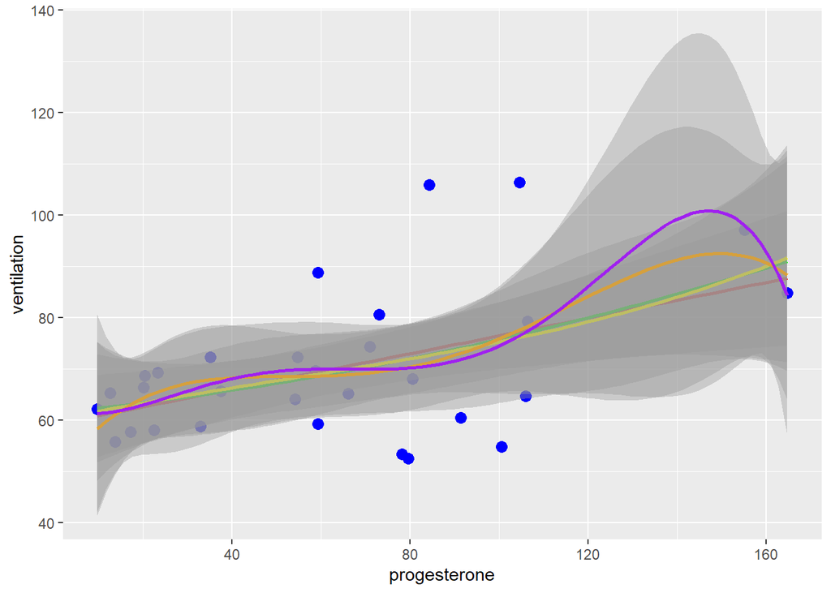

```r
# Load the data

brutsaert <- read.csv("chap17q07ProgesteroneExercise.csv")

# Plot the data

library(ggplot2)
pen_plot_base_Q1 <- ggplot(data = brutsaert,
                        mapping = aes(x = progesterone,
                                      y = ventilation))
pen_plot_base_Q1 +
  geom_point(size = 3,
             color = "blue") +
    stat_smooth(method = "lm", color = "red") + # linear fit
    stat_smooth(method="lm", color = "green", formula= y~poly(x,2)) + # quadratic
    stat_smooth(method="lm", color = "yellow", formula= y~poly(x,3)) + # third order polynomial
    stat_smooth(method="lm", color = "orange", formula= y~poly(x,4)) + # fourth order polynomial
    stat_smooth(method="lm", color = "purple", formula= y~poly(x,5)) # fifth order polynomial
```

```r
# Variables for lms for easy access

brutsaert_lm <- lm(ventilation ~ progesterone, data = brutsaert) # linear model
brutsaert_lm_quad <- lm(formula = ventilation ~ progesterone + I(progesterone^2), data = brutsaert) # quadratic model
brutsaert_lm_third <- lm(formula = ventilation ~ progesterone + I(progesterone^3), data = brutsaert) # third poly
brutsaert_lm_fourth <- lm(formula = ventilation ~ progesterone + I(progesterone^4), data = brutsaert) # fourth poly
brutsaert_lm_fifth <- lm(formula = ventilation ~ progesterone + I(progesterone^5), data = brutsaert) # fifth poly

# Get R^2s

summary(brutsaert_lm_fifth)$r.squared # fifth order polynomial fit
```

```
## [1] 0.2429203
```

```r
summary(brutsaert_lm)$r.squared # linear fit
```

```
## [1] 0.2371781
```

2. Fit each model with 5-fold CV

Does that result hold up, or is it due to overfitting? Let’s evaluate by comparing 5-fold CV scores using RMSE. Let’s do this efficiently, though!

A. Get things ready! Make a 5-fold cross validation tibble using rsample::vfold_cv() and then combine each possible fold with the polynomials 1:5 using tidyr::crossing()

```r
# Make a 5-fold cross validation tibble
cross_val_tibble <- rsample::vfold_cv(data = brutsaert, v = 5, strata = NULL)

# Combine each fold with a polynomial 1:5 using tidyr::crossing()

library(tidyr)
cross_val_tibble_crossing <- crossing(cross_val_tibble, polynomial_order = 1:5) # Create a tibble w polynomial orders using crossing

cross_val_tibble_crossing
```

```
## # A tibble: 25 x 3
##    splits         id    polynomial_order
##    <list>         <chr>            <int>
##  1 <split [24/6]> Fold1                1
##  2 <split [24/6]> Fold1                2
##  3 <split [24/6]> Fold1                3
##  4 <split [24/6]> Fold1                4
##  5 <split [24/6]> Fold1                5
##  6 <split [24/6]> Fold2                1
##  7 <split [24/6]> Fold2                2
##  8 <split [24/6]> Fold2                3
##  9 <split [24/6]> Fold2                4
## 10 <split [24/6]> Fold2                5
## # ... with 15 more rows
```

B. Now you have splits and a column of coefficients. Use purr::map2() to make a list column of fit models, where you use the splits and data and the polynomials for you poly() call in the model.

```r
library(dplyr)
```

```r
library(purrr)

# This code is adapted from Jarett's class code on cross validation

# Begin with the 5-fold tibble from A but set as a new tibble
cross_val_tibble_crossing_w_models <- cross_val_tibble_crossing %>%

  # create a new column mods, which we make with map
  # iterating over all of our splits
  mutate(fit_models = map2(splits,
                           polynomial_order,
                           #for each split, fit a model using
                           #the training data set
                           ~lm(ventilation ~ poly(progesterone, .y),
                               data = brutsaert)))

cross_val_tibble_crossing_w_models
```

```
## # A tibble: 25 x 4
##    splits         id    polynomial_order fit_models
##    <list>         <chr>            <int> <list>
##  1 <split [24/6]> Fold1                1 <lm>
##  2 <split [24/6]> Fold1                2 <lm>
##  3 <split [24/6]> Fold1                3 <lm>
##  4 <split [24/6]> Fold1                4 <lm>
##  5 <split [24/6]> Fold1                5 <lm>
##  6 <split [24/6]> Fold2                1 <lm>
##  7 <split [24/6]> Fold2                2 <lm>
##  8 <split [24/6]> Fold2                3 <lm>
##  9 <split [24/6]> Fold2                4 <lm>
## 10 <split [24/6]> Fold2                5 <lm>
## # ... with 15 more rows
```

C. Great! Now, calculate the rmse for each fold/polynomial combination as we did in lab.

```r
library(modelr)
library(rsample)

# extract the out of sample rmse for each model at each fold
# using a function called map2
x <- 1:10
y <- 11:20

map2_dbl(x, y, ~.x + .y)
```

```
##  [1] 12 14 16 18 20 22 24 26 28 30
```

```r
# start with our tibble
cross_val_tibble_crossing_3 <- cross_val_tibble_crossing_w_models %>%

  # create a new column, rmse, which we make with map2
  # iterating over all splits AND fit models
  mutate(rmse = map2_dbl(.x = splits, .y = fit_models,
                         ~rmse(model = .y,
                               data = assessment(.x))))

# Show that the rmse values for each fold are in the tibble
cross_val_tibble_crossing_3
```

```
## # A tibble: 25 x 5
##    splits         id    polynomial_order fit_models  rmse
##    <list>         <chr>            <int> <list>     <dbl>
##  1 <split [24/6]> Fold1                1 <lm>        13.7
##  2 <split [24/6]> Fold1                2 <lm>        14.0
##  3 <split [24/6]> Fold1                3 <lm>        14.1
##  4 <split [24/6]> Fold1                4 <lm>        14.7
##  5 <split [24/6]> Fold1                5 <lm>        14.9
##  6 <split [24/6]> Fold2                1 <lm>        11.9
##  7 <split [24/6]> Fold2                2 <lm>        11.8
##  8 <split [24/6]> Fold2                3 <lm>        11.7
##  9 <split [24/6]> Fold2                4 <lm>        11.3
## 10 <split [24/6]> Fold2                5 <lm>        10.9
## # ... with 15 more rows
```

Although, if you do that, quick note that you will need to use a map2_*() function with polys in it so that it’s variable can match the . variable used. This may seem like a weird sentence. But, once you get the error that made me realize this, you’ll get it.

We’re at the half-way point in the course, and after the mid-term, it’s time to start thinking about your final project. So…. I want to know a bit about what you’re thinking of!

A. What is the dataset you are thinking of working with? Tell me a bit about what’s in it, and where it comes from.

I would like to work with a dataset of historic precipitation events (perhaps within the past decade or two). I may be able to find the dataset on NOAA.gov. Working with this dataset would also help with my master’s thesis. The dataset may contain hourly precipitation values or daily precipitation values.

https://www.ncei.noaa.gov/metadata/geoportal/rest/metadata/item/gov.noaa.ncdc:C00313/html

B. What question do you want to ask of that data set?

I would like to check with my graduate advisor regarding the best question to ask. Some questions that come to mind are:

1. How many days with no rain (on average) pass between storm events? (this may be too simple)
2. What can be determined about extreme precipitation events? (e.g. how different they are in terms of precipitation level/depth from lesser storm events)
3. What is the likelihood of a subsequent high-precipitation storm occuring closely after a extreme high-precipitation event?